Claude Code Skill · Cardiometabolic Health Competitive Intelligence

# /cmh-ci — explore the PRD/QA landscape, then a guided BNMA, never a hardcoded script

Introduces what's actually in the data first — a complete outcome on its own if that's all you need — and, only when the goal is a full analysis, turns study selection from a silent, hand-edited R vector into a forced, traceable decision at every step — so a low-dose Phase 2 study or a naming mismatch can't quietly skew a competitive-landscape result again.

Model basis  
**Real production BNMA** confirmed against the actual CMH Shiny app **model_random.txt**: φ[i]~N(0, 0.0001) study baseline, δ[i,j] random treatment effect, σ~Unif(0,8)  
MCMC: adapt 10k · burn-in 10k · sample 20k (thin 10) · 3 chains  
Chain 1 inits φ/d to exactly 0; chains 2–3 draw from the same vague N(0, SD=100) prior  
Matches **EliLillyCo/CMH.BNMA**'s own documented spec verbatim (confirmed 2026-08-20)

What /cmh-ci helps you do

✓

**Explore the PRD/QA landscape** See what studies, compounds, phases, and evidence tiers are already in the data — a complete outcome on its own.

✓

**Add data from another source, if needed** Bring in a press release, a digitized slide, or a subset of another workbook when the PRD subset isn't enough.

✓

**Run a guided BNMA** Once the data's confirmed, fit the model and produce a forest plot with a reproducible driver script.

How /cmh-ci forces the decision

1

Introduce and explain the available PRD dataset Step 1

2

Ask which studies you're interested in — named studies/compounds, then scope (endpoint/route/evidence/region) Step 2

3

Naming & route-pooling QA gate + study list, reviewed together Step 3

4

Confirm the subset is sufficient, optionally bring in custom data Step 4-6

5

Confirm whether to proceed to a BNMA run at all — review/update-only is a complete outcome too Step 7

6

Generate the BNMA — folders, manifest, model input Step 8

7

Collect modelling preferences — heterogeneity, effect type Step 9

8

BATMAN + JAGS fit — the real production model model_random.txt

9

Forest plot, footnoted back to source data make_forest_plot.R

10

A driver script that reproduces the run from scratch run_bnma_*.R

Real forest plot output

Oral, Phase 3 weight-loss BNMA — absolute % body weight change, from an actual /cmh-ci run

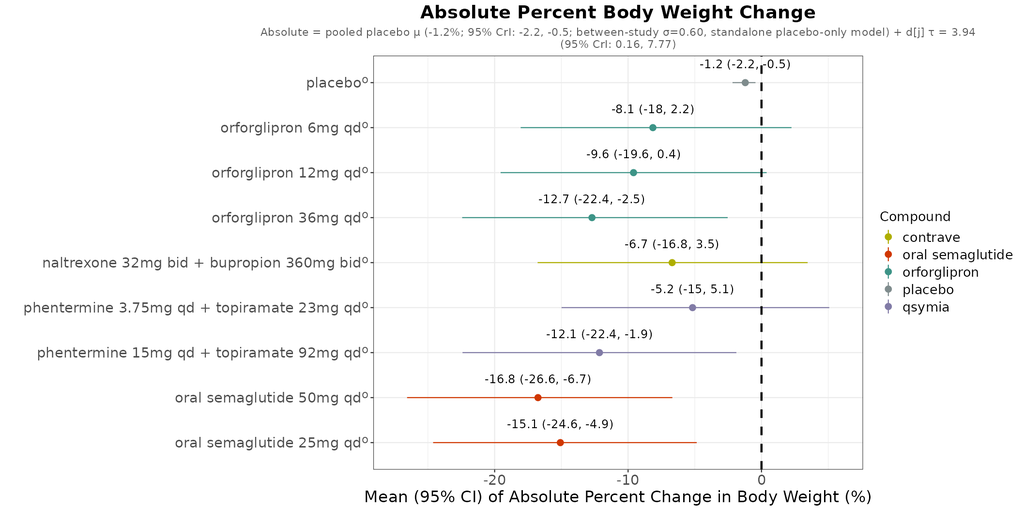

ᵒ = observed · full output also footnotes contributing studies and source data/program paths (cropped here for slide space)

.claude/skills/cmh-ci — cardiometabolic health competitive-intelligence QA/PRD dataset explorer + BNMA · mockup slide for team review; forest plot is a real run's output